# Plotting the phylogenetic tree and visualising our trait

- Show All Code
- Hide All Code
- View Source

Author

Daniel Padfield

Published

October 24, 2022

## Outline

This document plots the phylogenetic tree and visually examines the congruence between the tree and their taxonomic assignments. It then plots the habitat preference for each species/tip on the tree and we look at some simple descriptive statistics of the the habitat preferences.

## Load in R packages

```r
# load packages
library(here)
library(tidyverse)
library(ggtree)
library(ggnewscale)
library(RColorBrewer)
library(patchwork)
library(ape)
library(phytools)
library(MetBrewer)
```

## Load in data and do some data wrangling

There are three datasets that need aggregating for this analysis.

1. The ultrametric phylogenetic tree
2. The information on habitat preferences for each ASV
3. The taxonomic information for each ASV

We can load each in and then do some data wrangling.

```r
# set where I am in the project
here::i_am('scripts/sequencing_rpoB/analyses/plot_phylogeny.qmd')

# load in the tree
tree <- ape::read.tree(here('data/sequencing_rpoB/bamm/rerooted-pruned-chronopl10.tre'))

#tree$tip.label <- tolower(tree$tip.label)

# remove family name from the tip label
d_labels <- data.frame(tip_label = tree$tip.label) %>%
  separate(., tip_label, c('part1', 'part2', 'part3'), sep = '_', remove = FALSE) %>%
  unite('tip_label_new', c(part1, part2), sep = '_')

tree$tip.label <- d_labels$tip_label_new

# read in metadata
d_meta <- read.csv(here('data/sequencing_rpoB/processed/asv_metadata.csv'))

# read in habitat trait colours
cols_hab <- readRDS(here('data/sequencing_rpoB/processed/habitat_colours.rds'))
```

## Plot the tree with taxonomy and habitat preferences

We can now plot the taxonomic information on a plot with the habitat preferences to visualise the phylogenetic tree. This uses the R packages **ggtree** and **ggnewscale** to plot the tree and combine multiple colour scales respectively.

```r
# constrained families
constrained_families <- c('Myxococcaceae', 'Vulgatibacteraceae', 'Anaeromyxobacteraceae', 'Polyangiaceae', 'Sandaracinaceae', 'Nannocystaceae', 'Haliangiaceae')

# find 9 most common families based on number of tips assigned to them
d_common <- d_meta %>%
  group_by(family2) %>%
  tally() %>%
  ungroup() %>%
  mutate(., prop = n / sum(n)) %>%
  filter(., family2 %in% constrained_families)

sum(d_common$prop)
```

```
[1] 0.7562147
```

The families we used to constrain the tree represent 75% of all the tips.

We can now add these into the meta dataframe as a new column, and anything that is not assigned to one of these families will be assigned “uncommon”. To colour branches of the tree, we need to use **ggtree::groupOTU()**.

```r
# add in column for colouring branches
d_meta <- mutate(d_meta, family_common = ifelse(family2 %in% c(constrained_families, 'uncertain'), family2, 'unconstrained'))

# group tip labels together in terms of their order
to_group <- split(d_meta$tip_label, d_meta$family_common)
tree2 <- groupOTU(tree, to_group)
```

We are now ready to plot the phylogenetic tree. We will plot the tree with different colours for each family, and then place the colours of the habitat preferences around the tips of the tree.

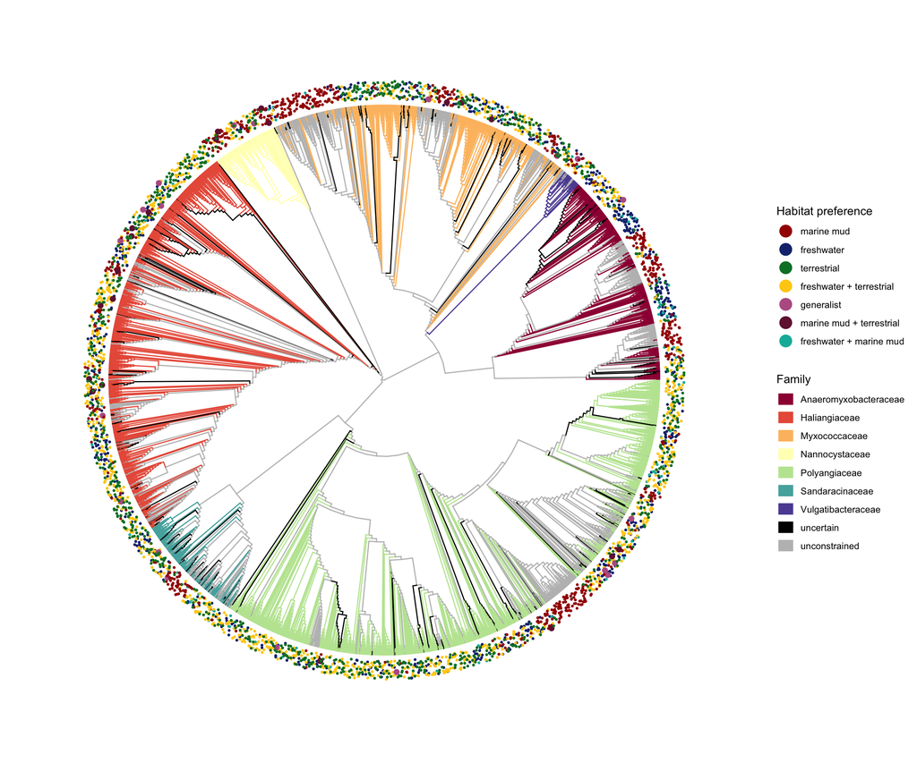

```r
# create colour palettes

# for different families - add in black and grey for uncertain and uncommon respectively
cols <- c(colorRampPalette(brewer.pal(11, "Spectral"))(nrow(d_common)), 'black', 'grey')
names(cols) <- c(d_common$family2, 'uncertain', 'unconstrained')

# for different habitat preferences
# I know Mick does not like the brown but I do not want two blues on the plot because it would be more difficult to tell them apart
cols_hab <- c('green4', '#1E90FE', 'sienna4', 'darkorange')
cols_hab <- met.brewer('Austria', n = 7)
names(cols_hab) <- c('mud_and_shore', 'freshwater', 'terrestrial', 'freshwater:terrestrial', 'generalist', 'mud_and_shore:terrestrial', 'freshwater:mud_and_shore')
hab_labels <- c('marine mud', 'freshwater', 'terrestrial', 'freshwater + terrestrial', 'generalist', 'marine mud + terrestrial', 'freshwater + marine mud')

# make a separate column for the rare states to make their size bigger!
d_meta <- mutate(d_meta, rare = ifelse(habitat_preference %in% c('generalist', 'mud_and_shore:terrestrial'), 'rare', 'common'))

# first only plot taxonomy
tree_plot <- ggtree(tree2, layout = 'circular', branch.length = 'none', aes(col = group)) %<+% filter(d_meta) +
  scale_color_manual('Family', values = cols) +
  guides(color = guide_legend(override.aes = list(size = 5)))

# now plot habitat preference around the tips
tree_plot2 <- tree_plot +
  theme_bw() +
  theme(panel.border = element_blank(),
        panel.grid.major = element_blank(),
        panel.grid.minor = element_blank(),
        axis.text.x = element_blank(),
        axis.text.y = element_blank(),
        axis.ticks = element_blank()) +
  new_scale_color() +
  geom_tippoint(aes(x=x+5, col = habitat_preference, size = rare), position = position_jitter(width = 3, height = 0)) +
  scale_color_manual('Habitat preference', values = cols_hab, labels = hab_labels) +
  scale_size_manual(values = c(0.6, 2)) +
  guides(color = guide_legend(override.aes = list(size = 5)),
         size = FALSE)

tree_plot2
```

```r
# save plot out
#ggsave(here('sequencing_rpoB/plots/analyses/tree_all_taxonomy.pdf'), tree_plot2, height = 9, width = 12)
ggsave(here('plots/sequencing_rpoB/analyses/tree_all_taxonomy.png'), tree_plot2, height = 9, width = 12)
```

Ok this looks pretty darn amazing. There are a couple of things to take home from this. The constrained tree does what it says it should do in terms of getting ASVs of the same family to be in the same clade. It is interesting that no unconstrained tips find their way into the Nannocystaceae but do find their way into all other clades.

We have coloured each trait state separately (seven colours). This allows us to better see the distribution of traits across the tree. Freshwater + terrestrial is extremely common all over the tree, whereas we see very specific clusters of marine mud specialists. We have made the very rare states (marine mud + terrestrial and generalist) have bigger points to see where they are, but there does not seem to be much clustering there. We found phylogenetic signal in the data previously by calculating Pagel’s lambda and the D-statistic for binary traits.

## What is our trait and what is its distribution?

Our trait is our own definition of habitat preference for each ASV identified as Myxococcota from our rpoB sequencing data. Briefly, for each ASV we:

- Calculated proportions of occurrence in each of the three habitat clusters identified from the 16S data (broadly these were terrestrial, freshwater, and marine mud).
- Bootstrapped a distribution of proportions of occurrences in each habitat by re-sampling 100 presences based on these proportions 1000 times.
- Compared these to the availability of each habitat cluster (different clusters had a different number of samples assigned to them)
- If your use of a habitat was significantly less than what if you just used what was available evenly (0.975 quantile of proportional use distribution was less than the proportion available) we say you did not favour that habitat.
- Your habitat preferences are defined as all the habitats you use at least as much as is expected by their availability.
- You can be freshwater, terrestrial, marine mud, or any combination of these.

We can look at the numbers of each of these and how many there are in each group.

```r
# first lets look at how many are in each group
group_by(d_meta, habitat_preference) %>%
  summarise(n = n(),
            ave_present = median(num_present)) %>%
  arrange(desc(n))
```

```
# A tibble: 7 × 3
  habitat_preference            n ave_present
  <chr>                     <int>       <dbl>
1 freshwater:terrestrial     1089           7
2 terrestrial                 835           5
3 freshwater                  759           6
4 mud_and_shore               702           5
5 freshwater:mud_and_shore    115           6
6 generalist                   20           6
7 mud_and_shore:terrestrial    20           5
```

## Useful links used

- [Documentation](https://yulab-smu.top/treedata-book/) of the R package **ggtree** used for plotting phylogenies.